# Homework

### Individual Homework

#### Enter your name here:Yen Hsi Lo(Steffi Lo)

```python
import pandas as pd
import numpy as np
import matplotlib.pyplot as plt
import seaborn as sns
```

**Analysis of movies IMDB dataset**

We will look at a **subset** sample of movies, taken from the [Kaggle IMDB 5000 movie dataset](https://www.kaggle.com/carolzhangdc/imdb-5000-movie-dataset)

```python
movies = pd.read_csv('../Data/movies.csv')
movies
```

|  | title | genre | director | year | duration | gross | budget | cast_facebook_likes | votes | reviews | rating |
| --- | --- | --- | --- | --- | --- | --- | --- | --- | --- | --- | --- |
| 0 | Avatar | Action | James Cameron | 2009 | 178 | 760505847 | 237000000 | 4834 | 886204 | 3777 | 7.9 |
| 1 | Titanic | Drama | James Cameron | 1997 | 194 | 658672302 | 200000000 | 45223 | 793059 | 2843 | 7.7 |
| 2 | Jurassic World | Action | Colin Trevorrow | 2015 | 124 | 652177271 | 150000000 | 8458 | 418214 | 1934 | 7.0 |
| 3 | The Avengers | Action | Joss Whedon | 2012 | 173 | 623279547 | 220000000 | 87697 | 995415 | 2425 | 8.1 |
| 4 | The Dark Knight | Action | Christopher Nolan | 2008 | 152 | 533316061 | 185000000 | 57802 | 1676169 | 5312 | 9.0 |
| ... | ... | ... | ... | ... | ... | ... | ... | ... | ... | ... | ... |
| 2956 | Locker 13 | Thriller | Bruce Dellis | 2014 | 95 | 2468 | 300000 | 2048 | 241 | 15 | 4.8 |
| 2957 | The Ghastly Love of Johnny X | Comedy | Paul Bunnell | 2012 | 106 | 2436 | 2000000 | 1611 | 344 | 113 | 5.7 |
| 2958 | Detention of the Dead | Comedy | Alex Craig Mann | 2012 | 87 | 1332 | 500000 | 2251 | 2038 | 49 | 4.6 |
| 2959 | The Trials of Darryl Hunt | Crime | Ricki Stern | 2006 | 106 | 1111 | 200000 | 2 | 771 | 21 | 7.7 |
| 2960 | The Jimmy Show | Comedy | Frank Whaley | 2001 | 96 | 703 | 1500000 | 920 | 480 | 30 | 5.4 |

2961 rows × 11 columns

Besides the obvious variables of `title`, `genre`, `director`, `year`, and `duration`, the rest of the variables are as follows:

- `gross` : The gross earnings in the US box office, not adjusted for inflation
- `budget`: The movie's budget
- `cast_facebook_likes`: the number of facebook likes cast memebrs received
- `votes`: the number of people who voted for (or rated) the movie in IMDB
- `reviews`: the number of reviews for that movie
- `rating`: IMDB average rating

**Produce a table with the count of movies by genre, ranked in descending order**

```python
table1 = (
    movies
    .groupby("genre")
    .agg(count=("genre", "count"))
    .sort_values("count", ascending=False)
)

print(table1)
```

```
             count
genre
Comedy         848
Action         738
Drama          498
Adventure      288
Crime          202
Biography      135
Horror         131
Animation       35
Fantasy         28
Documentary     25
Mystery         16
Sci-Fi           7
Family           3
Musical          2
Romance          2
Western          2
Thriller         1
```

**Produce a table with the average gross earning and budget (`gross` and `budget`) by genre. Calculate a variable `return_on_budget` which shows how many $ did a movie make at the box office for each $ of its budget. Ranked genres by this `return_on_budget` in descending order**

```python
table2 = (
    movies
    .groupby("genre")
    .agg(
        gross=("gross", "mean"),
        budget=("budget", "mean")
    )
    .assign(return_on_budget=lambda x: x["gross"] / x["budget"])
    .sort_values("return_on_budget", ascending=False)
)

print(table2)
```

```
                    gross        budget  return_on_budget
genre
Musical      9.208400e+07  3.189500e+06         28.870983
Family       1.491605e+08  1.483333e+07         10.055763
Western      2.082188e+07  3.465000e+06          6.009202
Documentary  1.735397e+07  5.887852e+06          2.947420
Horror       3.771374e+07  1.350492e+07          2.792593
Fantasy      4.240884e+07  1.758214e+07          2.412040
Comedy       4.263055e+07  2.444632e+07          1.743843
Mystery      6.753302e+07  3.921875e+07          1.721958
Animation    9.843379e+07  6.170143e+07          1.595324
Biography    4.520181e+07  2.854370e+07          1.583600
Adventure    9.579426e+07  6.629007e+07          1.445077
Drama        3.746537e+07  2.624293e+07          1.427637
Crime        3.750240e+07  2.659617e+07          1.410068
Romance      3.126485e+07  2.510750e+07          1.245239
Action       8.658386e+07  7.135489e+07          1.213426
Sci-Fi       2.978837e+07  2.760714e+07          1.079010
Thriller     2.468000e+03  3.000000e+05          0.008227
```

**Produce a table that shows the top 15 directors who have created the highest gross revenue in the box office. Don't just show the total gross amount, but also the mean, median, and standard deviation per director**

```python
table3=(movies
        .groupby("director")
        .agg(total_gross_amount=("gross","sum"),
             mean=("gross","mean"),
             median=("gross","median"),
             standard_deviation=("gross", "std")
             )
        .sort_values("total_gross_amount", ascending=False)

)
table3.head(15)
```

| director | total_gross_amount | mean | median | standard_deviation |
| --- | --- | --- | --- | --- |
| Steven Spielberg | 4014061704 | 1.745244e+08 | 164435221.0 | 1.014211e+08 |
| Michael Bay | 2231242537 | 1.716340e+08 | 138396624.0 | 1.271616e+08 |
| Tim Burton | 2071275480 | 1.294547e+08 | 76519172.0 | 1.087269e+08 |
| Sam Raimi | 2014600898 | 2.014601e+08 | 234903076.0 | 1.621266e+08 |
| James Cameron | 1909725910 | 3.182877e+08 | 175562880.5 | 3.091713e+08 |
| Christopher Nolan | 1813227576 | 2.266534e+08 | 196667606.5 | 1.872241e+08 |
| George Lucas | 1741418480 | 3.482837e+08 | 380262555.0 | 1.461939e+08 |
| Robert Zemeckis | 1619309108 | 1.245622e+08 | 100853835.0 | 9.130028e+07 |
| Clint Eastwood | 1378321100 | 7.254322e+07 | 46700000.0 | 7.548741e+07 |
| Francis Lawrence | 1358501971 | 2.717004e+08 | 281666058.0 | 1.354370e+08 |
| Ron Howard | 1335988092 | 1.113323e+08 | 101587923.0 | 8.193376e+07 |
| Gore Verbinski | 1329600995 | 1.899430e+08 | 123207194.0 | 1.544738e+08 |
| Andrew Adamson | 1137446920 | 2.843617e+08 | 279680930.5 | 1.208958e+08 |
| Shawn Levy | 1129750988 | 1.027046e+08 | 85463309.0 | 6.548477e+07 |
| Ridley Scott | 1128857598 | 8.063269e+07 | 47775715.0 | 6.881228e+07 |

**Produce a table that describes how ratings are distributed by genre. We don't want just the mean, but also, min, max, median, SD and some kind of a histogram or density graph that visually shows how ratings are distributed.**

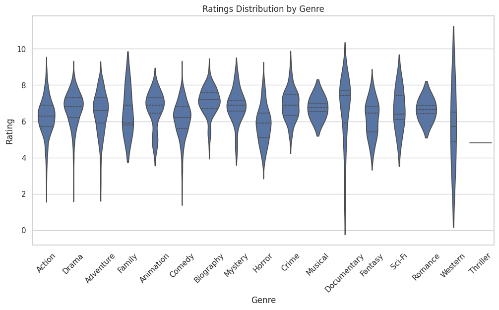

```python
table4=(movies
        .groupby("genre")
        .agg(mean=("rating","mean"),
             min=("rating","min"),
             max=("rating","max"),
             median=("rating","median"),
             SD=("rating", "std")
             )

)
table4

plt.figure(figsize=(12,6))
sns.violinplot(data=movies, x="genre", y="rating", inner="quartile")
plt.title("Ratings Distribution by Genre")
plt.xlabel("Genre")
plt.ylabel("Rating")
plt.xticks(rotation=45)
plt.show()
```

[output not shown]

**Challenge - Produce a table of your own choosing, something you think is important/interesting to have data for, justify your result by writting a 2 sentence explanation/interpretation of the result.**

```
                             title  return_on_budget  rating
466            Paranormal Activity       7194.485533     6.3
2772                     Tarnation       2715.660550     7.2
295        The Blair Witch Project       2342.168567     6.4
2302         The Brothers McMullen        409.864000     6.6
1609  The Texas Chain Saw Massacre        369.427285     7.5
...                            ...               ...     ...
2944                     Leap Year          0.000661     6.4
2951               Blonde Ambition          0.000556     3.9
2960                The Jimmy Show          0.000469     5.4
2925                 Winter's Tale          0.000374     6.2
2954                         Vamps          0.000185     5.1

[2961 rows x 3 columns]
Correlation between ROI and Rating: 0.012771821222054027
```

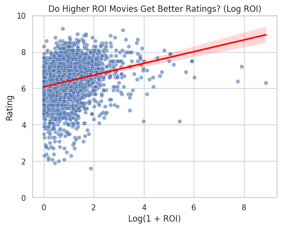

```
Since most ratings fall between 5 and 8, I applied a log transformation to ROI to better check whether high ratings are associated with high ROI.

The plot suggests that movies with high ROI are not necessarily highly rated, but they are also less likely to have extremely low ratings.
```

```python
import numpy as np
import pandas as pd
import seaborn as sns
import matplotlib.pyplot as plt

movies = movies.assign(return_on_budget=lambda x: x["gross"] / x["budget"])

table5 = (
    movies
    .loc[:, ["title", "return_on_budget", "rating"]]
    .sort_values("return_on_budget", ascending=False)
)
print(table5)

correlation = table5["return_on_budget"].corr(table5["rating"])
print("Correlation between ROI and Rating:", correlation)

movies["log_roi"] = np.log1p(movies["return_on_budget"])

sns.scatterplot(data=movies, x="log_roi", y="rating", alpha=0.6)
sns.regplot(data=movies, x="log_roi", y="rating", scatter=False, color="red")
plt.title("Do Higher ROI Movies Get Better Ratings? (Log ROI)")
plt.xlabel("Log(1 + ROI)")
plt.ylabel("Rating")
plt.ylim(0, 10)
plt.show()

#Since most of the ratings are between 5 to 8, I apply log on them to check "If the high rating means high ROI".
#The plot shows us that for those movies having high ROI, they are not necessarily high ratings, but not likely to be super-low ratings.

print(
    "Since most ratings fall between 5 and 8, I applied a log transformation to ROI "
    "to better check whether high ratings are associated with high ROI.\n"
)
print(
    "The plot suggests that movies with high ROI are not necessarily highly rated, "
    "but they are also less likely to have extremely low ratings."
)
```